# Confidence intervals: seminar demonstration

POLI 210 - Seminar 10

Author

Brad LeVeck

Published

November 4, 2026

This document runs on its own: it needs no downloaded data or helper files. Open it in RStudio and run the chunks in order, or use **Render** to run the whole document in a fresh session. The simulations use invented data with known population parameters so that we can check whether an interval covers its target. The turnout example uses rounded published summaries.

## 0. Setup

The calculations use base R. The graphs use `ggplot2`, and a few summaries use `dplyr`, both familiar from the last two seminars.

```r
# Install once if needed, in the Console:
# install.packages(c("ggplot2", "dplyr"))
library(ggplot2)
library(dplyr)

ci_colors <- c("Contains mu" = "#005a8b", "Misses mu" = "#b34b12")
theme_set(theme_minimal(base_size = 14))
```

## 1. From the turnout difference to an interval

The Neighbors mailing group had reported turnout of 37.8%; the Civic Duty group had 31.5%. These are the rounded figures used in Blackwell’s lecture from Gerber, Green, and Larimer (2008). A turnout indicator is 1 for a voter and 0 otherwise, so its sample mean is the turnout proportion.

For two **independent** samples, estimate the SE of their mean difference by

$$\widehat{\operatorname{SE}}(\widehat D)
=\sqrt{S_Y^2/n_Y+S_X^2/n_X}.$$

Here we use the plug-in Bernoulli variance $\hat p(1-\hat p)$ with the rounded proportions. Using sample variances instead would multiply each variance by $n/(n-1)$, a negligible difference for these group sizes.

```r
p_neigh <- .378
n_neigh <- 38201
p_civic <- .315
n_civic <- 38218

estimate <- p_neigh - p_civic
se_diff <- sqrt(p_neigh * (1 - p_neigh) / n_neigh +
                p_civic * (1 - p_civic) / n_civic)
critical <- qnorm(.975)
turnout_ci <- estimate + c(-1, 1) * critical * se_diff

data.frame(estimate_pp = 100 * estimate,
           se_pp = 100 * se_diff,
           lower_pp = 100 * turnout_ci[1],
           upper_pp = 100 * turnout_ci[2])
```

```
  estimate_pp     se_pp lower_pp upper_pp
1         6.3 0.3435201 5.626713 6.973287
```

Multiplying by 100 changes proportions into **percentage points**.

**Design qualification:** this is a classroom independent-samples calculation, not a reproduction of the paper’s uncertainty estimates. The original treatment was assigned to households, so inference for that study must respect household assignment and dependence. A formula alone does not establish that its assumptions fit a study.

## 2. Simulate a single interval

Let $X_1,\ldots,X_n$ be independent draws from $N(1,10)$, where 10 is the **variance**. R’s `rnorm()` asks for the standard deviation, `sqrt(10)`.

```r
set.seed(2143)
mu <- 1
sigma <- sqrt(10)
n <- 500
x <- rnorm(n, mean = mu, sd = sigma)

estimate <- mean(x)
se <- sd(x) / sqrt(n)
critical <- qnorm(.975)
lower <- estimate - critical * se
upper <- estimate + critical * se

data.frame(estimate, se, lower, upper,
           covers = lower <= mu & mu <= upper)
```

```
  estimate        se     lower    upper covers
1 1.085147 0.1406655 0.8094477 1.360846   TRUE
```

The parameter `mu` stays fixed. Drawing another sample changes `mean(x)`, `sd(x)`, and the two endpoints. The Normal cutoff is an approximation here because we estimated the population SD. At $n=500$ it works very well.

## 3. Repeat the sampling process and measure coverage

`n` counts observations **within** each sample; `B` counts independent **repetitions** of the whole experiment. We reset the seed so that the first sample below is the same one as in Section 2.

```r
set.seed(2143)
mu <- 1
sigma <- sqrt(10)
n <- 500
B <- 10000
critical <- qnorm(.975)

ci <- data.frame(trial = seq_len(B),
                 estimate = rep(NA_real_, B),
                 se = rep(NA_real_, B),
                 lower = rep(NA_real_, B),
                 upper = rep(NA_real_, B))

for (i in seq_len(B)) {
  x <- rnorm(n, mean = mu, sd = sigma)
  ci$estimate[i] <- mean(x)
  ci$se[i] <- sd(x) / sqrt(n)
  ci$lower[i] <- ci$estimate[i] - critical * ci$se[i]
  ci$upper[i] <- ci$estimate[i] + critical * ci$se[i]
}

ci <- ci |>
  mutate(covers = lower <= mu & mu <= upper,
         result = if_else(covers, "Contains mu", "Misses mu"))

ci |>
  summarise(repetitions = n(),
            coverage = mean(covers),
            average_width = mean(upper - lower))
```

```
  repetitions coverage average_width
1       10000   0.9498     0.5541993
```

`mean(covers)` treats `TRUE` as 1 and `FALSE` as 0. It estimates $P(L\leq\mu\leq U)$, the procedure’s coverage probability.

### Plot the first 100 intervals

Each vertical segment comes from a different sample. The horizontal line marks the same population mean in every repetition.

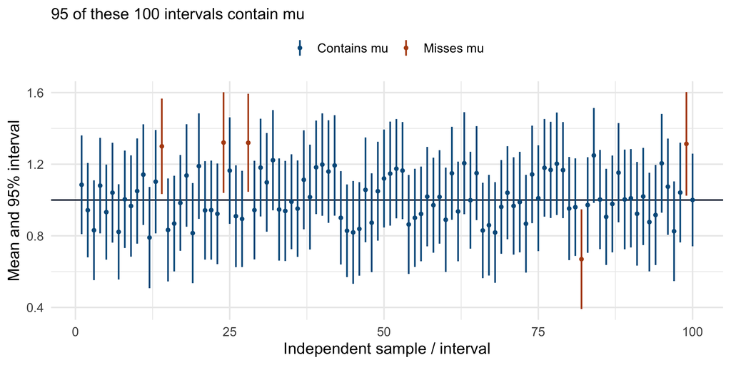

```r
first100 <- ci |> slice_head(n = 100)

ggplot(first100, aes(x = trial, y = estimate, color = result)) +
  geom_hline(yintercept = mu, color = "#172d42") +
  geom_linerange(aes(ymin = lower, ymax = upper), linewidth = .7) +
  geom_point(size = 1.1) +
  scale_color_manual(values = ci_colors) +
  labs(x = "Independent sample / interval", y = "Mean and 95% interval",
       color = NULL,
       subtitle = paste(sum(first100$covers), "of these 100 intervals contain mu")) +
  theme(legend.position = "top")
```

We should not expect exactly 95 covering intervals in every batch of 100. The simulation also has sampling error. The SE of our estimated coverage is approximately

$$\sqrt{\widehat p(1-\widehat p)/B}.$$

```r
coverage <- mean(ci$covers)
mcse <- sqrt(coverage * (1 - coverage) / B)
c(coverage = coverage, Monte_Carlo_SE = mcse)
```

```
      coverage Monte_Carlo_SE
   0.949800000    0.002183574
```

Increasing `B` measures coverage more precisely. It does not narrow any individual study’s confidence interval. Increasing `n` changes the study’s information and, typically, its interval width.

## 4. Change the confidence level while holding the sample fixed

For a two-sided interval, split $\alpha$ equally between the two tails. The positive Normal cutoff has probability $1-\alpha/2$ to its left.

```r
levels <- c(.90, .95, .99)
widths <- data.frame(level = levels,
                     estimate = ci$estimate[1],
                     se = ci$se[1]) |>
  mutate(alpha = 1 - level,
         critical = qnorm(1 - alpha / 2),
         lower = estimate - critical * se,
         upper = estimate + critical * se,
         width = upper - lower)
widths
```

```
  level estimate        se alpha critical     lower    upper     width
1  0.90 1.085147 0.1406655  0.10 1.644854 0.8537729 1.316521 0.4627483
2  0.95 1.085147 0.1406655  0.05 1.959964 0.8094477 1.360846 0.5513987
3  0.99 1.085147 0.1406655  0.01 2.575829 0.7228167 1.447477 0.7246607
```

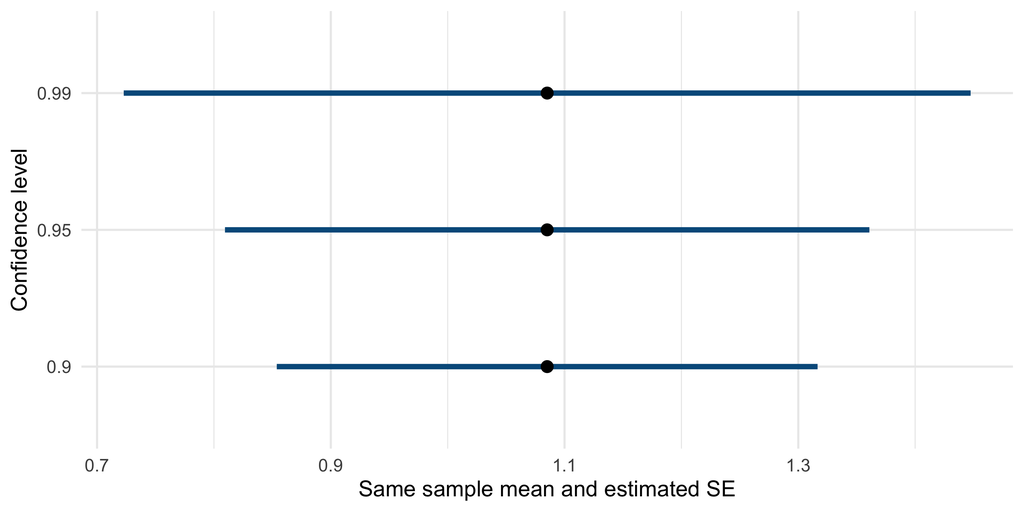

```r
ggplot(widths, aes(y = factor(level), x = estimate)) +
  geom_segment(aes(x = lower, xend = upper, yend = factor(level)),
               linewidth = 1.6, color = "#005a8b") +
  geom_point(size = 3) +
  labs(x = "Same sample mean and estimated SE", y = "Confidence level")
```

**Try:** add `.80` to `levels` and rerun this chunk. Predict how its width will compare before looking at the graph.

For a fixed critical value and population SD, the theoretical margin of error shrinks at rate $1/\sqrt n$:

```r
data.frame(n = c(25, 100, 400)) |>
  mutate(SE = sqrt(10) / sqrt(n),
         margin = qnorm(.975) * SE)
```

```
    n        SE    margin
1  25 0.6324555 1.2395901
2 100 0.3162278 0.6197950
3 400 0.1581139 0.3098975
```

This last calculation holds the **population** SD fixed; in a real sample, the estimated SD also varies. More data cannot repair a biased sampling process merely by producing a smaller SE.

## 5. One statistic, two justifications

Our main argument allows us to estimate the SE. For iid observations with finite, positive variance,

$$T_n=\frac{\overline X-\mu}{S/\sqrt n}
=\frac{\sigma}{S}\frac{\sqrt n(\overline X-\mu)}{\sigma}
\xrightarrow{d}N(0,1).$$

The CLT gives the Normal limit for the second factor. Consistency of the sample SD makes the first approach 1. The observations themselves need not be Normal. This justifies large-sample intervals using an estimated SE.

If we additionally assume iid **Normal** observations, this same statistic has exactly a $t_{n-1}$ distribution. A $t$ cutoff then supplies exact finite-sample coverage. We use that special case in the calculation below.

PSD writes $t_{\alpha/2}$ for the **positive upper-tail cutoff**. R uses left-tail probabilities by default: `qt(1 - alpha/2, df = n - 1)`.

```r
set.seed(210)
x <- rnorm(10, mean = 1, sd = sqrt(10))
n <- length(x)
level <- .95
alpha <- 1 - level

se <- sd(x) / sqrt(n)
critical <- qt(1 - alpha / 2, df = n - 1)
manual_ci <- mean(x) + c(-1, 1) * critical * se
manual_ci
```

```
[1] -0.982085  3.693462
```

```r
# Same positive cutoff, written using the upper tail:
qt(alpha / 2, df = n - 1, lower.tail = FALSE)
```

```
[1] 2.262157
```

```r
# Extract just the confidence interval from t.test's output:
automatic_ci <- t.test(x, conf.level = level)$conf.int
automatic_ci
```

```
[1] -0.982085  3.693462
attr(,"conf.level")
[1] 0.95
```

```r
all.equal(as.numeric(automatic_ci), as.numeric(manual_ci))
```

```
[1] TRUE
```

`$conf.int` selects the interval component of the result. The remaining `t.test()` output concerns hypothesis testing, which we will develop separately. The interval concerns the unknown **population mean**; the sample mean is the number already calculated by `mean(x)`.

### Compare the two reference distributions

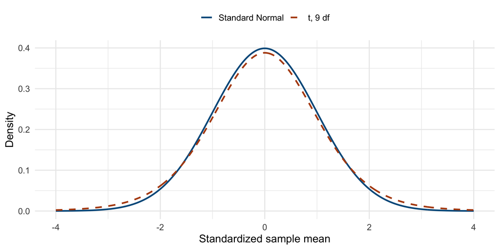

```r
grid <- data.frame(z = seq(-4, 4, length.out = 1001)) |>
  mutate(normal_density = dnorm(z), t_density = dt(z, df = 9))

ggplot(grid, aes(x = z)) +
  geom_line(aes(y = normal_density, color = "Standard Normal"), linewidth = 1) +
  geom_line(aes(y = t_density, color = "t, 9 df"), linewidth = 1, linetype = 2) +
  scale_color_manual(values = c("Standard Normal" = "#005a8b", "t, 9 df" = "#b34b12")) +
  labs(x = "Standardized sample mean", y = "Density", color = NULL) +
  theme(legend.position = "top")
```

```r
c(Normal_cutoff = qnorm(.975), t_cutoff = qt(.975, df = 9))
```

```
Normal_cutoff      t_cutoff
     1.959964      2.262157
```

## 6. Why a t cutoff also works asymptotically

For a fixed confidence level, the $t$ critical value approaches the Normal critical value as its degrees of freedom increase:

```r
cutoff_comparison <- data.frame(n = c(10, 30, 100, 500)) |>
  mutate(t_cutoff = qt(.975, df = n - 1),
         normal_cutoff = qnorm(.975))
cutoff_comparison
```

```
    n t_cutoff normal_cutoff
1  10 2.262157      1.959964
2  30 2.045230      1.959964
3 100 1.984217      1.959964
4 500 1.964729      1.959964
```

Consequently, under the broad conditions in Section 5, either cutoff gives asymptotically correct coverage. Choosing a $t$ cutoff does not require us to claim an exact $t$ distribution for our statistic. In small non-Normal samples, its larger cutoff still does not guarantee 95% coverage.

### Check the Normal benchmark

The following function compares the two intervals on the **same samples**. It uses a known Normal population so that the special exact $t$ result holds. All population parameters are defined inside the function.

```r
compare_normal <- function(n, B = 10000) {
  mu <- 1
  sigma <- sqrt(10)
  zcrit <- qnorm(.975)
  tcrit <- qt(.975, df = n - 1)

  stats <- replicate(B, {
    x <- rnorm(n, mean = mu, sd = sigma)
    c(estimate = mean(x), se = sd(x) / sqrt(n))
  })
  z_covers <- abs(stats["estimate", ] - mu) <= zcrit * stats["se", ]
  t_covers <- abs(stats["estimate", ] - mu) <= tcrit * stats["se", ]

  data.frame(n = n, cutoff = c("Normal", "t"),
             critical = c(zcrit, tcrit),
             simulated_coverage = c(mean(z_covers), mean(t_covers)),
             theoretical_coverage = c(2 * pt(zcrit, df = n - 1) - 1, .95))
}

set.seed(2110)
normal_results <- bind_rows(compare_normal(10), compare_normal(500))
normal_results
```

```
    n cutoff critical simulated_coverage theoretical_coverage
1  10 Normal 1.959964             0.9170            0.9183509
2  10      t 2.262157             0.9476            0.9500000
3 500 Normal 1.959964             0.9502            0.9494439
4 500      t 1.964729             0.9506            0.9500000
```

`replicate()` returns a matrix with one column per repetition. The named rows keep track of each repetition’s estimate and SE. The theoretical Normal-cutoff coverage uses the *actual* $t$ distribution of the statistic: $P(-1.96\leq T_{n-1}\leq1.96)$, using the unrounded cutoff in the code.

Under this Normal model, at $n=10$ the Normal cutoff gives an interval that is too narrow too often. At $n=500$, the two critical values and their coverage are very close. We now check how that conclusion changes with population shape.

## 7. Check robustness to a skewed population

We now keep the population mean and variance at 1 but change its shape. A Normal population satisfies the exact $t$ result. An Exponential population is strongly right-skewed; its $t$ interval is only approximate.

```r
coverage_t <- function(n, population, B = 10000) {
  mu <- 1
  critical <- qt(.975, df = n - 1)
  covers <- replicate(B, {
    x <- if (population == "Normal") rnorm(n, 1, 1) else rexp(n, rate = 1)
    margin <- critical * sd(x) / sqrt(n)
    mean(x) - margin <= mu && mu <= mean(x) + margin
  })
  p <- mean(covers)
  c(coverage = p, mcse = sqrt(p * (1 - p) / B))
}

set.seed(2111)
robustness <- expand.grid(n = c(10, 30, 100, 500),
                          population = c("Normal", "Exponential"),
                          stringsAsFactors = FALSE)
robustness$coverage <- NA_real_
robustness$mcse <- NA_real_
for (i in seq_len(nrow(robustness))) {
  result <- coverage_t(robustness$n[i], robustness$population[i])
  robustness$coverage[i] <- result["coverage"]
  robustness$mcse[i] <- result["mcse"]
}
robustness
```

```
    n  population coverage        mcse
1  10      Normal   0.9506 0.002167017
2  30      Normal   0.9521 0.002135547
3 100      Normal   0.9538 0.002099180
4 500      Normal   0.9541 0.002092682
5  10 Exponential   0.8940 0.003078376
6  30 Exponential   0.9268 0.002604645
7 100 Exponential   0.9430 0.002318426
8 500 Exponential   0.9459 0.002262149
```

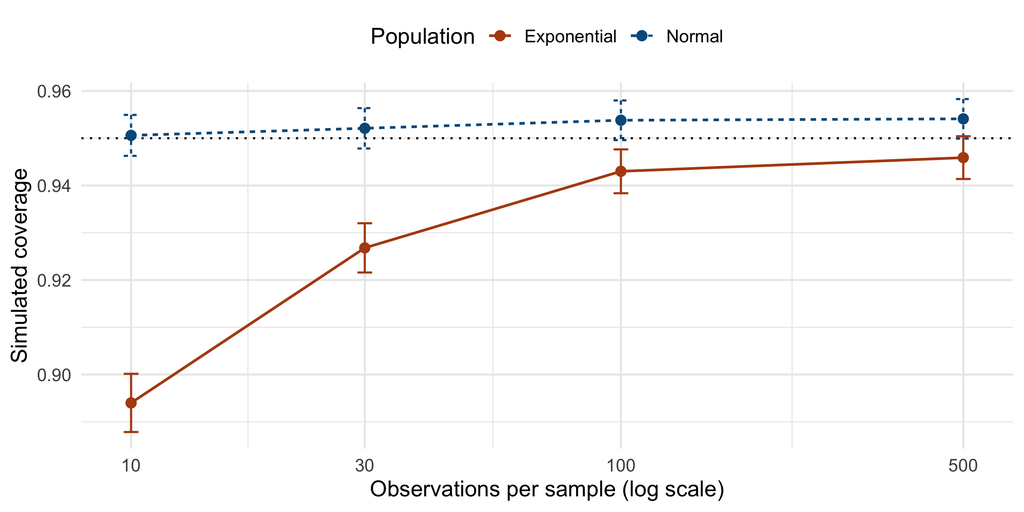

```r
ggplot(robustness, aes(n, coverage, color = population, linetype = population)) +
  geom_hline(yintercept = .95, linetype = 3) +
  geom_line(linewidth = .8) +
  geom_errorbar(aes(ymin = coverage - 2 * mcse, ymax = coverage + 2 * mcse),
                width = .03) +
  geom_point(size = 2.5) +
  scale_x_log10(breaks = c(10, 30, 100, 500)) +
  scale_color_manual(values = c("Exponential" = "#b34b12", "Normal" = "#005a8b")) +
  labs(x = "Observations per sample (log scale)", y = "Simulated coverage",
       color = "Population", linetype = "Population") +
  theme(legend.position = "top")
```

The whiskers here describe **Monte Carlo uncertainty in estimated coverage**, not uncertainty in the mean from any single study. Distinguish two questions:

1. How close are the $t$ and Normal critical values?
2. How well does either reference distribution approximate the actual statistic?

The first can be excellent while the second is still poor. The Exponential population meets our broad asymptotic conditions, but its finite-sample coverage can fall below 95%. There is no universal sample-size cutoff that guarantees a good approximation.

## Optional: 100 ratings are not 100 independent voters

Imagine 20 independently sampled voters, each rating a candidate five times. A voter’s ratings share a personal underlying evaluation. We use an unbounded Normal model for these hypothetical scores to keep the dependence example transparent.

```r
set.seed(2112)
mu <- 50
people <- 20
repeats <- 5
person_mean <- rnorm(people, mean = mu, sd = 10)
ratings <- data.frame(
  voter = rep(seq_len(people), each = repeats),
  rating = rnorm(people * repeats, mean = rep(person_mean, each = repeats), sd = 5)
)

voter_means <- ratings |>
  group_by(voter) |>
  summarise(rating = mean(rating), .groups = "drop")

naive <- t.test(ratings$rating)$conf.int
by_voter <- t.test(voter_means$rating)$conf.int
data.frame(method = c("Treat all 100 rows as independent", "Use 20 voter means"),
           lower = c(naive[1], by_voter[1]),
           upper = c(naive[2], by_voter[2]))
```

```
                             method    lower    upper
1 Treat all 100 rows as independent 50.43867 54.41070
2                Use 20 voter means 48.21958 56.62979
```

With equally many observations per voter, averaging the 20 voter means and averaging all 100 ratings give the same point estimate. Their SEs differ.

```r
set.seed(2113)
B <- 5000
panel_coverage <- replicate(B, {
  person_mean <- rnorm(20, mean = 50, sd = 10)
  ratings <- matrix(rnorm(100, mean = rep(person_mean, each = 5), sd = 5),
                    nrow = 5, ncol = 20)
  # Each column contains one voter's five ratings.
  voter_means <- colMeans(ratings)
  raw_ratings <- as.vector(ratings)
  naive_margin <- qt(.975, 99) * sd(raw_ratings) / sqrt(100)
  voter_margin <- qt(.975, 19) * sd(voter_means) / sqrt(20)
  c(naive = abs(mean(raw_ratings) - 50) <= naive_margin,
    voter_means = abs(mean(voter_means) - 50) <= voter_margin)
})
rowMeans(panel_coverage)
```

```
      naive voter_means
     0.6364      0.9480
```

This model gives independent Normal voter means, so a $t$ interval on those means has exact coverage. Averaging within people is appropriate here because the design is balanced and the target is the mean across voters; it is not a universal solution for every form of clustered or time-series data.

## Optional: one-sided bounds and the test connection

A lower confidence bound puts the entire error probability in one tail. Its positive cutoff is `qt(.95, df)` rather than `qt(.975, df)`.

```r
set.seed(210)
x <- rnorm(10, mean = 1, sd = sqrt(10))
n <- length(x)
lower_bound <- mean(x) - qt(.95, n - 1) * sd(x) / sqrt(n)
lower_bound
```

```
[1] -0.5386993
```

```r
t.test(x, alternative = "greater", conf.level = .95)$conf.int
```

```
[1] -0.5386993        Inf
attr(,"conf.level")
[1] 0.95
```

For the corresponding two-sided test, a proposed mean $\mu_0$ falls outside the 95% interval exactly when its standardized distance exceeds the two-sided critical value.

```r
mu0 <- 0
se <- sd(x) / sqrt(n)
ci95 <- mean(x) + c(-1, 1) * qt(.975, n - 1) * se
outside <- mu0 < ci95[1] || mu0 > ci95[2]
beyond_cutoff <- abs((mean(x) - mu0) / se) > qt(.975, n - 1)
c(outside_interval = outside, beyond_test_cutoff = beyond_cutoff)
```

```
  outside_interval beyond_test_cutoff
             FALSE              FALSE
```

Choose one-sided versus two-sided inference before examining the result. A value’s presence inside the interval does not prove it is the true mean. PSD §§8.3–8.4 develop the testing framework; the core demonstration above only needs confidence intervals and coverage.

## Sources

The main sequence and Normal coverage experiment adapt Matthew Blackwell’s *Gov 2000: Estimation and Statistical Inference*, Section 3, pp. 32–49, with permission. The $t$ interval and robustness comparisons connect to [*Probability, Statistics, and Data*, §§8.1–8.5](https://probstatsdata.com/HTCI.html). The turnout summaries come from Gerber, Green, and Larimer (2008), “Social Pressure and Voter Turnout: Evidence from a Large-Scale Field Experiment,” *American Political Science Review*, 102(1), 33–48.